# Tag Checking: Why? How?

Larissa Goulart

**Overview**

In this workshop we will talk about tagging your texts and tag checking. To do the tag checking of our texts we will use two tools developed by the [CROW team](https://writecrow.org/). This is a step by step overview of this workshop:

1.Introduction to tagging

2.Precision and recall

3.Tool to check precision

4.Tool to check precision and recall

5.Practice

# 1 Introduction to tagging

To annotate, or tag, a corpus means to add information to each individual token. This information can be grammatical, semantic, pragmatic etc. These tags (or labels) can be used to compare frequencies of determined linguistic feature across texts, or group of texts. In addition, adding Part-of-Speech information to our texts allows us to differentiate between words that have the same spelling (e.g. claim - noun, claim-verb).

In this workshop, we will be talking about part-of-speech annotation, or the first level of this tree-diagram.

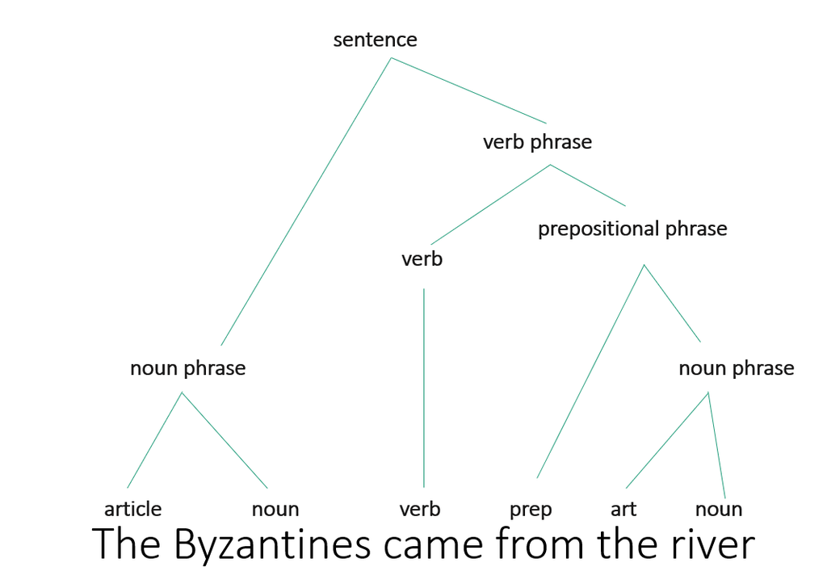

There are different softwares or packages you could use to tag your text (TreeTagger, Stanford Parser, CLAWS, etc) each of these softwares has a different tagset and will give you a different output. A Tagset is the set of labels a tagger can identify, for instance, [this](http://ucrel.lancs.ac.uk/claws7tags.html) is the tagset for CLAWS. The figure below compares the output of three taggers (Stanford Parser, CLAWS and the Biber Tagger) for the same text. What differences can you notice between outputs?

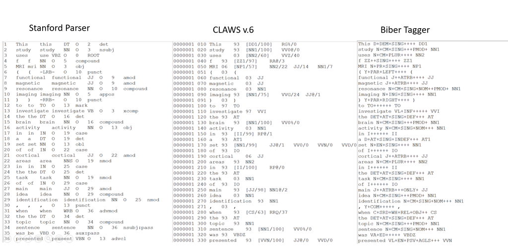

## 1.1 The Biber Tagger output

In this workshop, we will be doing tag checking in the tags of the Biber Tagger. The Biber Tagger outputs the text with each word in the text in the vertical followed by the tag. The tag and the word are separated by a space and every tag has seven tag fields followed by another space and the original CLAWS tag.

`women N+CM+PLUR++++ NN2`

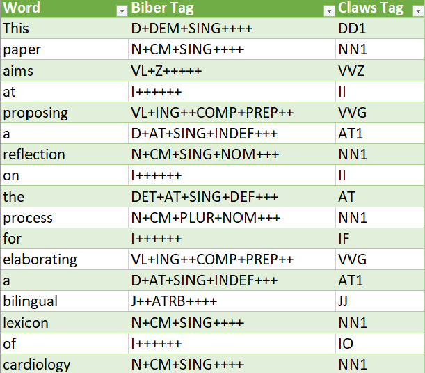

If you would like to understand better the difference between the Biber Tagger and other taggers, I recommend [Gray (2019)](https://drive.google.com/file/d/19cqJLx-yU0xByi2zYUKYnLDcZrmCoh0p/view?usp=sharing).

## 1.2 Biber Tagger tagset

Going back to my previous example `women N+CM+PLUR++++ NN2`, we know that `N+CM+PLUR++++` is the tag, but now we need to know what each tagfield means. Don’t forget that a tagfield is the label between `+` like this:

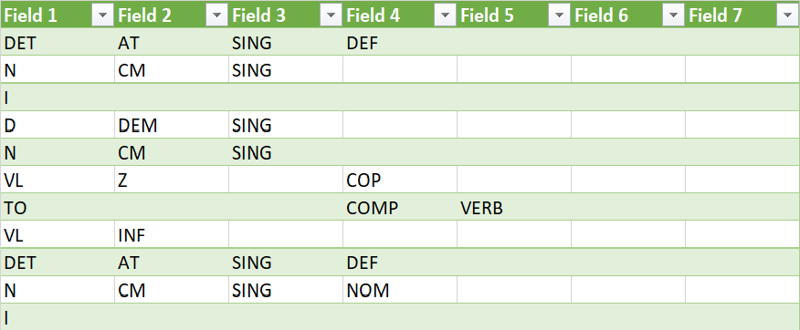

The fact that the Biber Tagger has seven tagfields means that we get up to seven pieces of information in one label, for instance, `N+CM+PLUR++++` means that `women` is a noun `N`, but it is also a common noun `CM`, in its plural form `PLUR`. The table below shows the complete tagset.

ï..legend

CLAWS7.Tag

Biber.Tag

category

dash

Y+DSH+++

punctuation

comma

,

Y+COM+++

punctuation

semicolon

;

Y+SCOL+CLP++

punctuation

colon

:

Y+COL+CLP++

punctuation

exclamation mark

!

Y+EXCL+CLP++

punctuation

question mark

?

Y+QUE+CLP++

punctuation

single quote mark

’

Y+APO+++

punctuation

double quote mark

"

Y+QUO+++

punctuation

left parenthesis

(

Y+PAR+LEFT++

punctuation

right parenthesis

)

Y+PAR+RIGHT++

punctuation

third person impersonal possessive determiner

APPGE

D+IMPR++3+GE++

determiners

singular first person possessive determiner

APPGE

D+PER+SING+1+GE++

determiners

second person possessive determiner

APPGE

D+PER++2+GE++

determiners

plural first person possessive determiner

APPGE

D+PER+PLUR+1+GE++

determiners

plural third person personal possessive determiner

APPGE

D+PER+PLUR+3+GE++

determiners

singular third person personal possessive determiner

APPGE

D+PER+SING+3+GE++

determiners

article

AT

D+AT+++++

determiners

definite article

AT

D+AT++DEF+++

determiners

singular definite article

AT

D+AT+SING+DEF+++

determiners

singular indefinite article

AT1

D+AT+SING+INDEF+

determiners

multi-word infinitive marker

BCL

TO+++++MULTI+

coordinating conjunction

CC

C+C++++

coordinators

coordinating conjunction + clausal connector

CC

C+C+CLS+++

coordinators

coordinating conjunction + phrasal connector

CC

C+C+PHRS+++

coordinators

adversative coordinating cojunction

CCB

C+C+++ADVS+

conjunction

conditional subordinating conjunction

CS

C+S+CND++

subordinators

concessive subordinating conjunction

CS

C+S+CON++

subordinators

subordinating conjunction

CS

C+S+++

subordinators

WH subordinating conjunction

CSW

C+S+WH++++

subordinators

pronominal post-determiner

DA

D+DA+PRO++++

determiners

singular post-determiner

DA1

D+DA+SING++++

determiners

plural post determiner

DA2

D+DA+PLUR++++

determiners

comparative after-determiner

DAR

D+DA+ER++++

determiners

superlative after-determiner

DAT

D+DA+EST+++

determiners

pre-quantifier

DB

D+DB+++++

determiners

pre-quantifier / double conjunction

DB2

D+DB+DOUB++

determiners

singular determiner

DD

D++SING++++

determiners

plural determiner

DD

D++PLUR+++

plural determiner with pronominal function

DD

D++PLUR++PRO++

singular determiner with pronominal function

DD

D++SING++PRO++

determiners

singular demonstrative determiner

DD1

D+DEM+SING++++

determiners

singular demonstrative pronoun

DD1

P+DEM+SING++

pronouns

plural demonstrative determiner

DD2

D+DEM+SING++++

determiners

plural demonstrative pronoun

DD2

P+DEM+PLUR++

pronouns

WH-determiner

DDQ

D++WH++++

WH-words

WH-determiner as clause head

DDQ

D++WH+CLS+++

WH-words

WH-determiner as queston word

DDQ

D++WH+QUE+++

WH-words

genitive WH-relativizer

DDQGE

D+REL+WH++++

WH-words

genitive WH-determiner

DDQGE

D++WH+GE+++

WH-words

genitive WH-determiner as a question word

DDQGE

D++WH+GE+QUE++

WH-words

genitive WH-determiner as extraposed clause head

DDQGE

D++WH+CLS+GE++EXT

WH-words

WH-ever determiner

DDQV

D++WH+++EVER+

WH-words

WH-ever determiner as clause head

DDQV

D++WH+CLS++EVER+

WH-words

WH-ever determiner as question word

DDQV

D++WH+QUE++EVER++

WH-words

existential there

EX

P+EX+++++

pronouns

formula symbols

FO

FO++++

punctuation

unclassified word

FU

FU++++

unclassified

ain’t as an auxiliary verb

FU

VA+AI++++BE+

verbs

ain’t as a main verb

FU

VL+AI++++BE+

verbs

foreign word

FW

FW++++

foreign words

genitive marker

GE

G++++

genitive

multi-word preposition

II/IO/IW

I+++++MULTI+

prepositions

preposition

II/IO/IW

I++++

prepositions

stranded preposition

II/IO/IW

I+STR+++

prepositions

attributive adjective

JJ

J++ATRB++++

adjectives

predicative adjective

JJ

J++PRED+++

adjectives

attributive-only adjective

JJ

J++ATRB+++ONLY+

adjectives

comparative attributive adjective

JJR

J++ATRB+ER++

adjectives

comparative predicative adjective

JJR

J++PRED+ER++

adjectives

superlative attributive adjective

JJT

J++ATRB+EST++

adjectives

superlative predicative adjective

JJT

J++PRED+EST++

adjectives

cardinal number

MC

M+C+++

numbers

singular cardinal number greater than one

MC

M+C+SING+MORE++

numbers

year

MC

M+C+++

numbers

singular cardinal number equal to one

MC1

M+C+SING+ONE++

numbers

plural cardinal number equal to one

MC2

M+C+PLUR+ONE++

numbers

plural cardinal number not equal to one

MC2

M+C+PLUR+MORE++

numbers

hyphenated number

MCMC

M+C+++HYPH++

numbers

ordinal number

MD

M+D+++

numbers

fraction

MF

M+F+++

numbers

singular noun of direction

ND1

N++SING++DIR++

nouns

common noun neutral for number

NN

N+CM+NEUT++++

nouns

singular common noun

NN1

N+CM+SING++

nouns

plural common noun

NN2

N+CM+PLUR++

nouns

post-nominal titular noun

NNA

N+PR+++TIT+A

nouns

pre-nominal titular noun

NNB

N+PR+++TIT+B

nouns

plural locative noun

NNL2

N++PLUR++L+

nouns

numeral noun neutral for number

NNO

N++++O++

numbers

plural numeral noun

NNO2

N++PLUR++O+

numbers

unit of measurement neutral for number

NNU

N++++U++

nouns

singular unit of measurement

NNU1

N++SING++U+

nouns

plural unit of measurement

NNU2

N++PLUR++U+

nouns

proper noun neutral for number

NP

N+PR+++

nouns

singular proper noun

NP1

N+PR+SING++

nouns

plural proper noun

NP2

N+PR+PLUR++

nouns

singular day of the week

NPD1

N+PR+SING++DAY++

nouns

plural day of the week

NPD2

N+PR+PLUR++DAY++

nouns

singular month of the year

NPM1

N+PR+SING++M++

nouns

plural month of the year

NPM2

N+PR+PLUR++M+

nouns

neutral number indefinite pronoun

PN

P++NEUT+INDEF++++

pronouns

indefinite pronoun

PN1

P+++INDEF+++

pronouns

WH-pronoun as question word

PNQS

P+WH+QUE++

WH-words

WH-ever pronoun

PNQV

P+WH++EVER+

WH-words

indefinite reflexive pronoun

PNX1

P+++INDEF+X++

pronouns

possessive personal pronoun

PPGE

P+PER+++POS

pronouns

third person impersonal pronoun

PPH1

P+IM++3+

pronouns

singular third person personal object pronoun

PPHO1

P+PER+SING+3+O

pronouns

plural third person personal object pronoun

PPHO2

P+PER+PLUR+3+O

pronouns

singular third person personal subject pronoun

PPHS1

P+PER+SING+3+S

pronouns

plural third person personal subject pronoun

PPHS2

P+PER+PLUR+3+S

pronouns

singular first person object pronoun

PPIO1

P+PER+SING+1+O

pronouns

plural first person object pronoun

PPIO2

P+PER+PLUR+1+O

pronouns

singular first person subject pronoun

PPIS1

P+PER+SING+1+S

pronouns

plural first person subject pronoun

PPIS2

P+PER+PLUR+1+S

pronouns

singular reflexive first person pronoun

PPX1

P+PER+SING+1+X

pronouns

singular second person reflexive pronoun

PPX1

P+PER+SING+2+X

pronouns

singular reflexive third person personal pronoun

PPX1

P+PER+SING+3+X

pronouns

plural reflexive first person pronoun

PPX2

P+PER+PLUR+1+X

pronouns

plural reflexive third person personal pronoun

PPX2

P+PER+PLUR+3+X

pronouns

second person pronoun

PPY

P+PER++2++

pronouns

adverb after nominal head

RA

R+A+++

adverbs

adverb introducing appositional constructions

REX

R+++++APP+

adverbs

degree adverb

RG

R+++++DEG+

adverbs

wh-degree adverb

RGQ

R+G+WH++

WH-words

comparative degree adverb

RGR

R+++ER++DEG+

adverbs

comparative adverb (between aux. verb and main verb)

RGR

R+++ER+SPLT++

adverbs

superlative degree adverb

RGT

R+++EST++DEG+

adverbs

place marker adverb

RL

R+++++PL+

adverbs

locative adverb

RL

R+L+++++

adverbs

adverbial particle

RP

R+PART+++

adverbs

adverb

RR

R++++++

adverbs

WH-Adverb

RRQ

R++WH++

WH-words

wh-adverb as clause head

RRQ

R++WH+CLS+

WH-words

wh-adverb as question word

RRQ

R++WH+QUE+

WH-words

wh-adverb as extraposed clause head

RRQ

R+WH++CLS+++EXT

WH-words

WH-ever adverb

RRQV

R++WH+++EVER+

WH-words

comparative adverb

RRR

R+++ER+++

adverbs

superlative adverb

RRT

R+++EST+++

adverbs

quasi-nominal adverb of time

RT

R+T+++

adverbs

infinitive marker

TO

TO++++

to

to as extraposed clause head

TO

TO++++++EXT

to

interjection/filler

UH

UH++++

interjections

base form of be as auxiliary verb

VB0

VA+BF++++BE+

verbs

be as main verb

VB0

VL+0+++

verbs

being as a main verb

VBG

VL+ING+++++

verbs

being as an auxiliary verb

VBG

VA+ING++++BE+

verbs

being as a present progressive postnominal modifier

VBG

VL+ING++REL+NOUN++

verbs

be as an infinitive main verb

VBI

VL+INF++++BE+

verbs

contracted am as auxiliary verb

VBM

VA+AM+++CONT+BE+

verbs

contracted am as main verb

VBM

VL+AM+++CONT++

verbs

am as main verb

VBM

VL+M+++

verbs

been as an auxiliary verb

VBN

VA+EN++BE+++

verbs

been as a main verb

VBN

VL+EN+++++

verbs

contracted are as auxiliary verb

VBR

VA++++CONT+BE+

verbs

are as main verb

VBR

VL+Z+++

verbs

contracted are as main verb

VBR

VL+Z+++CONT

verbs

is as an auxiliary verb

VBZ

VA+Z++++BE+

verbs

is as an auxiliary verb (contracted)

VBZ

VA+Z+++CONT+BE+

verbs

base form of do as auxiliary verb

VDD

VA+++++DO+

verbs

did as a main verb

VDD

VL+ED++++DO+

verbs

base form of do as main verb

VDD0

VL+BF++++DO+

verbs

doing as a present progressive verb

VDG

VL+ING+PRG++DO+

verbs

doing as a present progressive postnominal modifier

VDG

VL+ING++REL++DO+

verbs

do as an infinitive main verb

VDI

VL+INF+++DO+

verbs

does as a main verb

VDZ

VL+EN++++DO+

verbs

does as an auxiliary verb

VDZ

VA+Z++++DO+

verbs

base form of have as main verb

VH0

VL+BF++++HV+

verbs

contracted have as main verb

VH0

VL+0+++CONT

verbs

had as a past simple main verb

VHD

VL+ED++++HV+

verbs

having as a main verb

VHG

VL+ING++++HV+

verbs

have as an infinitive main verb

VHI

VL+ING++++HV+

verbs

had as a past participle main verb

VHN

VL+EN++++HV+

verbs

has as a main verb

VHZ

VL+Z++++HV+

verbs

necessity modal

VM

VM+++++NEC+

modals

necessity modal (contracted)

VM

VM++++CONT+NEC+

modals

possibility modal

VM

VM+++++POS+

modals

possibility modal (contracted)

VM

VM++++CONT+POS+

modals

prediction modal

VM

VM+++++PRDN+

modals

prediction modal (contracted)

VM

VM++++CONT+PRDN+

modals

multi-word periphrastic necessity modal

VMK

VM+++++NEC+MULTI

modals

uninflected present tense and imperative base form of verb

VV0

VL+BF+++++

verbs

present progressive verb

VVG

VL+ING+PROG++++

verbs

present progressive postnominal modifier

VVG

VL+ING++REL+NOUN++

verbs

present participle verb (indeterminate function)

VVG

VL+ING+++++

verbs

infinitive as main verb

VVI

VL+INF+++++

verbs

infinitive of be as auxiliary verb

VVI

VA+INF++++BE+

verbs

past participle verb

VVN

VL+EN+++++

verbs

perfect aspect past participle verb

VVN

VL+EN+PRF++++

verbs

agentless passive verb

VVN

VL+EN+PSV+AGLS++

verbs

by passive verb

VVN

VL+EN+PSV+BY++

verbs

third person verb

VVZ

VL++Z++++

verbs

not

XX

XX++++

adverbs

contracted not

XX

XX++++CONT++

adverbs

punctuation

Y

Y++++

punctiation

ellipsis

YLIP

Y+ELIP+++

punctuation

full-stop/period

YSTP

Y+PER+++

punctuation

singular letter of the alphabet

ZZ1

ZZ++SING++

nouns

plural letter of the alphabet

ZZ2

ZZ++PLUR++

nouns

percent sign

Y+PCT+++

punctuation

multi-word coordinating conjunction

C+C++++MULTI+

coordinators

multi-word subordinating conjunction

C+S++++MULTI+

subordinators

causative subordinating conjunction

C+S+CAUS++

subordinators

double conjunction

C++DOUB++++

determiners

preposition from a prepositional verb

I+PPVB+++

prepositions

singular past participle noun

N+EN+SING++++

nouns

singular nominalization

N++SING+NOM++

nouns

plural nominalization

N++PLUR+NOM+

nouns

singular titular noun

N+PR+SING+TIT++

nouns

singular present participle noun

N+ING+SING++++

nouns

multi-word adverb

R++++++MULTI

adverbs

negative adverb

R+++++NEG+

adverbs

adverb (between aux. verb and main verb)

R++++SPLT++

adverbs

adverbial particle (between aux. verb and main verb)

R+PART+++SPLT++

adverbs

adverb conjunct

R+CJ+++

adverbs

conjunctive adverb (between aux. verb and main verb)

R+CJ+++SPLT++

adverbs

discourse particle

R++DSPT++

adverbs

discourse particle (between aux. verb and main verb)

R++DSPT+SPLT+

adverbs

phrasal verb adverb

R+PART+PHRV++

adverbs

place marker adverb (between aux. verb and main verb)

R++++SPLT+PL+

adverbs

time marker adverb

R+TM+++

adverbs

time marker adverb (between aux. verb and main verb)

R+TM++SPLT+

adverbs

comparative time marker adverb

R+TM+R++

adverbs

comparative time marker adverb (between aux. verb and main verb)

R+TM+R+SPLT+

adverbs

place marker adverbial particle

R+PART++++PL+

adverbs

place marker adverbial particle (between aux. verb and main verb)

R+PART+++SPLT+PL+

adverbs

that as complementizer in adjective complement clause

C+S+COMP+THT+ADJ+

that

that as complementizer in noun complement clause

C+S+COMP+THT+NOUN+

that

that as relativizer in relative clause

C+S+REL+++

that

that as relativizer in object-gap relative clause

C+S+REL+OBJ++

that

that as relativizer in subject-gap relative clause

C+S+REL+SUB++

that

that as complementizer in verb complement clause

C+S+COMP+THT+VERB+

that

had as an auxiliary verb

VA+ED++++HV+

WH-relativizer

P+WH+REL+OBJ++

WH-words

WH-relativizer with object gap and prepositional fronting (pied piping)

P+WH+REL+OBJ+PIED+

WH-words

WH-relativizer with subject gap

P+WH+REL+SUB++

WH-words

WH-pronoun

P++WH+++

WH-words

conditional subordinating conjunction as extraposed clause head

C+S+CND+CLS+++EXT

subordinators

WH subordinating conjunction as extraposed clause head

C+S+WH+CLS+++EXT

WH-determiner as extraposed clause head

D++WH+CLS+++EXT

WH-words

plural indefinite article

D+AT+PLUR+INDEF+++

determiners

plural indefnite article with pronominal function

D+AT+PLUR+INDEF+PRO++

WH-determiner as extraposed clause head

D+WH++CLS+EX

WH-words

past participle adjective

J+EN+++++

adjectives

present participle adjective

J+ING+++++

adjectives

number

M++++++

numbers

date

M+T+++++

numbers

pre-modifying noun

N+++++PMOD++

nouns

plural past participle noun

N+EN+PLUR++++

nouns

plural present participle noun

N+ING+PLUR++++

WH-pronoun as extraposed clause head

P++WH+CLS+++EXT

WH-words

dummy it

P+IM++3+EXT

pronouns

singular reflexive third person impersonal pronoun

P+IMPR+SING+3+X

multi-word adverb (between aux. verb and main verb)

R++++SPLT++MULTI

adverbs

WH Adverb as subordinator

R+S+WH+CLS+++

subordinators

that as a extraposed clause head

THT+++CLS+++EXT

that

are as an auxilliary verb

VA+++++BE+

am as an auxilliary verb

VA+AM++++BE+

be as a auxiliary verb

VA+BF++++BE+

contracted have as an auxilliary verb

VA+BF+++CONT+HV+

was or were as an auxilliary verb

VA+ED++++BE+

contracted had as an auxilliary verb

VA+ED+++CONT+HV+

done as an auxiliary verb

VA+EN++++DO+

infinitive of do as an auxiliary verb

VA+INF++++DO+

infinitive of have as an auxilliary verb

VA+INF++++HV+

doing as an auxiliary verb

VA+ING++++DO+

having as an auxilliary verb

VA+ING++++HV+

has as an auxilliary verb

VA+Z++++HV+

contracted has as an auxilliary verb

VA+Z+++CONT+HV

base form of copular verb

VL+++COP+++

verbs

past participle verb as adverbial clause

VL+EN++CLS+ADVL++

past participle of copular verb

VL+EN++COP+++

perfect aspect copular verb

VL+EN+PERF+COP+++

infinitive of copular verb

VL+INF++COP+++

doing as main verb

VL+ING++++DO+

present participle verb in adverbial clause

VL+ING++CLS+ADVL++

extraposed ing participle clause

VL+ING++COMP+++EXT

present participle as object of prepositional phrase

VL+ING++COMP+PREP++

present participle verb complement clause

VL+ING++COMP+VERB++

present participle copular verb

VL+ING++COP+++

present progressive copular verb

VL+ING+PROG+COP+++

third person copular verb

VL+Z++COP+++

present-tense semi-modal

VM++++++MULTI

modals

no tense semi-modal

VM++NO++++MULTI

modals

third-person semi-modal

VM++Z+++MULTI

past-tense semi-modal

VM+ED+++++MULTI

modals

left bracket

Y+BRAC+LEFT++

punctuation

right bracket

Y+BRAC+RIGHT++

punctuation

dollar sign

Y+DOL+++

punctuation

hashtag?

Y+HASH+++++

You can download the table [here](https://www.dropbox.com/s/5g9s4btwt6f9k84/new_bt_tagset.csv?dl=0).

# 2 Precision and Recall

After we tagged our texts, it is important to check the precision and recall of our tags to make sure that we are counting what we think we are counting. In the following text, for example, how many noun (`NN`) tags do we have? and how many are not accurate?

| ï..Word | Tag | Lemma |
| --- | --- | --- |
| This | DT | this |
| study | NN | study |
| uses | NN | use |
| F-MRI | NP | MRI |
| ( | ( | ( |
| functional | NN | functional |
| magnetic | NN | magnetic |
| resonance | NN | resonance |
| imaging | NN | imaging |
| ) | ) | ) |
| to | TO | to |
| investigate | VV | investigate |
| the | DT | the |
| brain | NN | brain |
| activity | NN | activity |
| in | IN | in |
| a | DT | a |
| set | NN | set |
| of | IN | of |
| cortical | NN | cortical |
| areas | NNS | area |
| in | IN | in |
| the | DT | the |
| task | NN | task |
| of | IN | of |
| main | JJ | main |
| idea | NN | idea |
| identification | NN | identification |
| , | , | , |
| when | WRB | when |

[output cut: 169 more lines]

## 2.1 Calculating precision and recall

Precision is the percentage of the tags that are correct. Recall is the percentage of the tags that were correctly identified. Confusing? I find the following image helpful when trying to understand the idea of precision and recall.

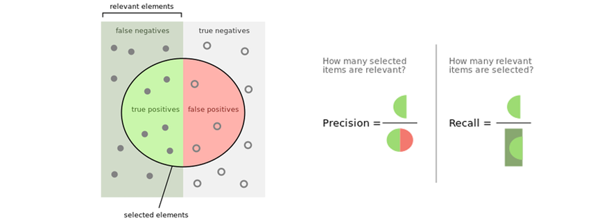

We calculate precision and recall by using the following formula.

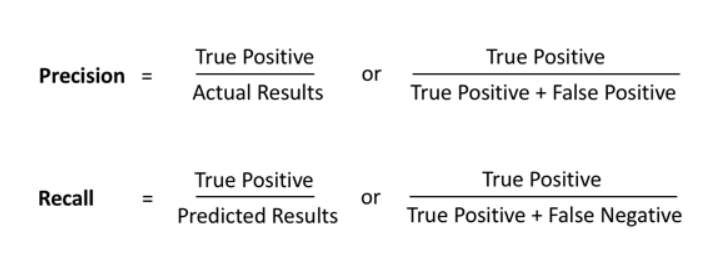

For example, if we search for `NN` here is how we would count true/false positives and true/false negatives.

| Original.Tag | Correct.Tag | Count |
| --- | --- | --- |
| NN | RB | False Positive |
| NN | NN | True Positive |
| RB | NN | Fase Negative |
| NN | NN | True Positive |
| RB | RB | True Negative |
| RB | RB | True Negative |

# 3 Tool to check precision

The [New Biber Tag Checking Tool](http://htmlpreview.github.io/?https://github.com/lg845/coding_tools/blob/master/New_BT_subset_tag_checker/index.html) simply helps us search for one tag at a time. When we find error in the tag and fix, it gives us the precision for that specific tag.

1. We need to decide on a tag to search for, the default search is set to `PMOD` right now, but you can change to any tag in the tagset.

[figure not shown]

2. Input a tagged text

[figure not shown]

3. Check if the highlighted words are correctly tagged

[figure not shown]

All the words that are highlighted contain the tag you input in your search.

4. Fix the tags that are wrong

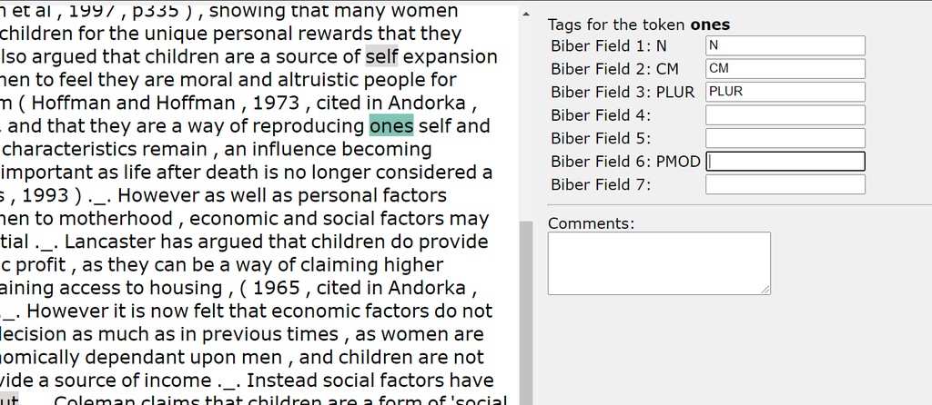

In this example, I deleted the PMOD.

5. Check precision

Once you start making changes in the tags, this will appear on the top of your screen.

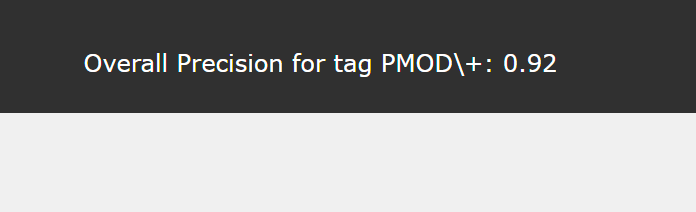

6. Save the tag checked file

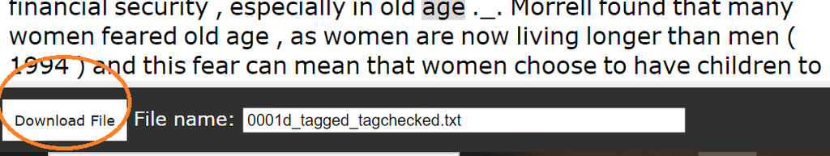

If you want to continue searching for the same tag just input another file, or if you want to search for another tag click on `Clear Tool`

In this workshop I am showing the tool online, but you can download the html file from github and run it offline too.

**Bonus**: if you are taking INF502 or you want to practice your Git skills, you can clone the repo to your computer, [link here](https://github.com/writecrow/coding_tools.git)

# 4 Tool to check precision and recall

The [Biber Tag Checking Tool](http://htmlpreview.github.io/?https://github.com/lg845/coding_tools/blob/master/biber_tag_checker/index.html) looks the same as the previous tool, but the difference is that you can check the precision for every token in a text, this way you can check for both precision and recall.

1. Input a tagged text

[figure not shown]

2. Click on the first word in the text

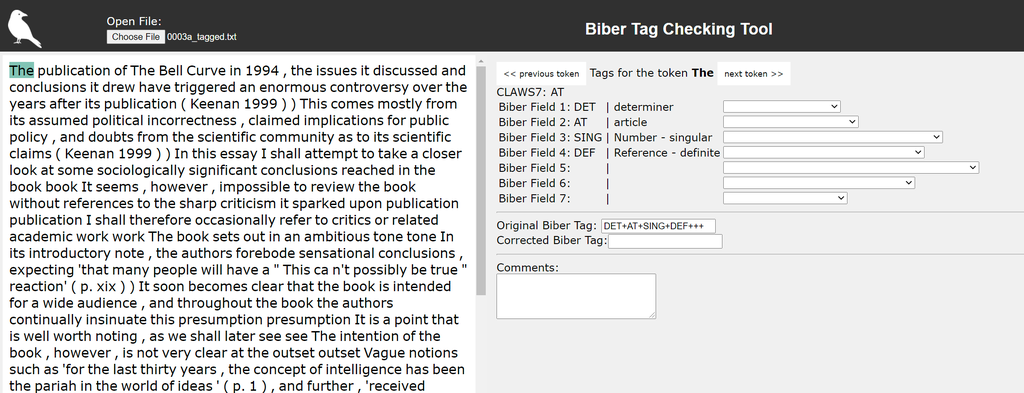

3. Use the `<<` and `>>` menus to move to the next token

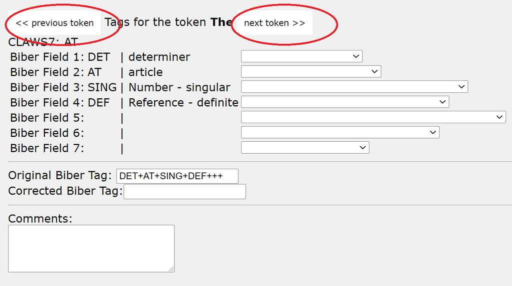

4. Use the dropdown menus to fix incorrect tags

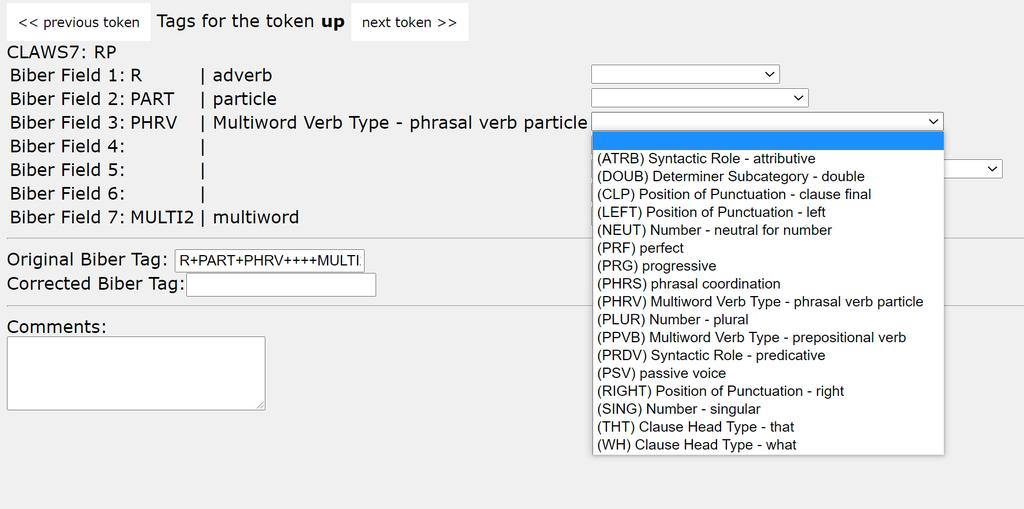

5. Check the new tag

When you make changes to a tag the new Biber Tag will appear

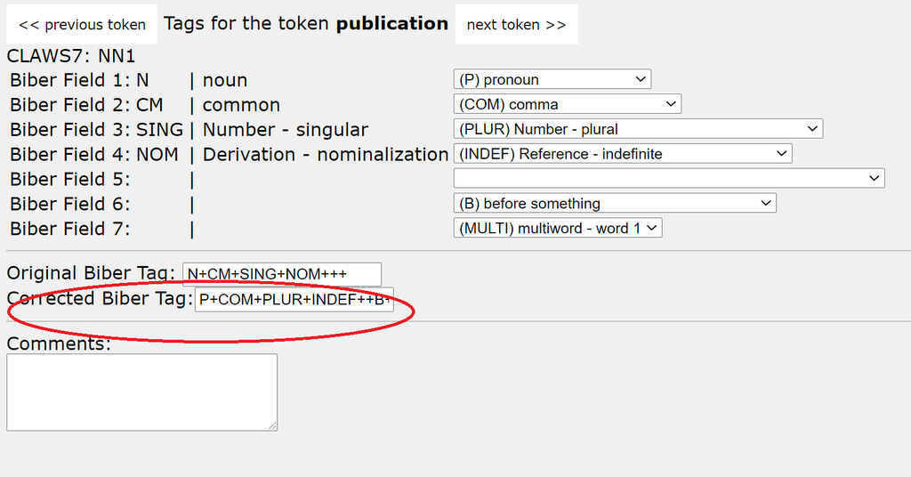

6. Track your progress

You can check the percentage of the text that you have tag checked by looking at the `token #` at the top of the page.

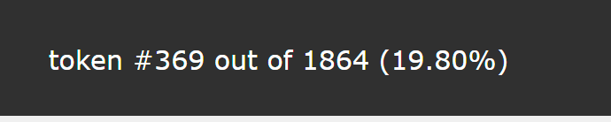

7. Save your tag checked file

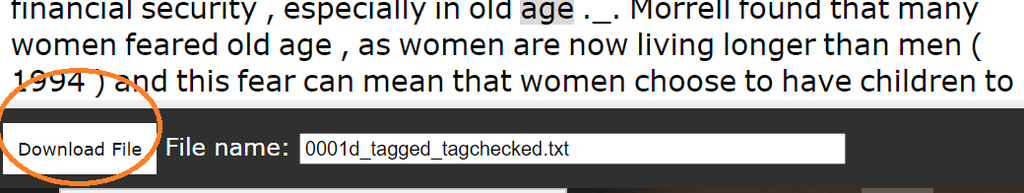

8. Precision and Recall

To calculate precision and recall after tag checking, you can open your file with excel and compare the column with the original tags and the edited ones. It will look like this:

| ï..Column1 | Column2 | Column3 | Column4 | Column5 |
| --- | --- | --- | --- | --- |
| Token | Original_Biber_Tags | Original_Claws_Tag | New_Biber_Tags | Comments |
| The | DET+AT+SING+DEF+++ | AT | ++++++ |  |
| publication | N+CM+SING+NOM+++ | NN1 | P+COM+PLUR+INDEF++B+MULTI1 |  |
| of | I++++++ | IO | ++++++ |  |
| The | DET+AT+SING+DEF+++ | AT | ++++++ |  |
| Curve | N+PR+SING++++ | NN1 | ++++++ |  |
| concept | N+CM+SING++++ | NN1 | ++++++ |  |
| of | I++++++ | IO | ++++++ |  |
| intelligence | N+CM+SING+NOM+++ | NN1 | ++++++ |  |
| has | VL+Z+++++ | VHZ | DET+CM+++++ |  |
| been | VL+EN+PRF+COP+++ | VBN | ++++++ |  |
| the | DET+AT+SING+DEF+++ | AT | ++++++ |  |
| pariah | N+CM+SING++++ | NN1 | ++++++ |  |
| expressing | VL+ING++COMP+PREP++ | VVG | ++++++ |  |
| a | D+AT+SING+INDEF+++ | AT1 | ++++++ |  |
| person | N+CM+SING++++ | NN1 | DET+COL+RIGHT++++ |  |
| ’s | GE++++++ | GE | ++++++ |  |
| intelligence | N+CM+SING+NOM+++ | NN1 | ++++++ |  |
| intelligence | ++++++ |  | ++++++ |  |
| Especially | R++++++ | RR | ++++++ |  |
| right’ | J++ATRB++++ | JJ | ++++++ |  |
| ( | Y+PAR+LEFT++++ | ( | ++++++ |  |
| Miele | N+PR+SING++++ | NP1 | EX+DOL+PPVB++++ |  |
| 1995 | M+CARD+SING+MORE+++ | MC | ++++++ |  |
| ) | Y+PAR+RIGHT++++ | ) | ++++++ |  |

**This is just an example, the tags are not correct and I cut a part of the text**

# 5 Precision and Recall on Excel

Looking at the results of the table below, we can calculate precision and recall by marking the ones that are `true positive`, `false positives` and `false negatives`.

| ï..Original_Biber_Tags | New_Biber_Tags | Comments |
| --- | --- | --- |
| DET+AT+SING+DEF+++ |  |  |
| N+CM+SING+NOM+++ | P+COM+PLUR+INDEF++B+MULTI1 | False Positive |
| I++++++ | ++++++ |  |
| DET+AT+SING+DEF+++ | ++++++ |  |
| N+PR+SING+++PMOD+ | JJ+COM+++++ | False Positive |
| N+PR+SING++++ | JJ+COM+++++ | False Positive |
| I++++++ | ++++++ |  |
| M+CARD+SING+MORE+++ | ++++++ |  |
| Y+COM+++++ | ++++++ |  |
| DET+AT+SING+DEF+++ | ++++++ |  |
| N+CM+PLUR++++ | JJ+COM+++++ | False positive |
| P+IM++3+++ | ++++++ |  |
| VL+ED+++++ | ++++++ |  |
| C+CRD+++++ | ++++++ |  |
| N+CM+PLUR++++ | ++++++ | True Positive |
| P+IM++3+++ | ++++++ |  |
| VL+ED+++++ | ++++++ |  |
| VL+BF+++++ | ++++++ |  |
| VL+EN+PRF++++ | ++++++ |  |
| D+AT+SING+INDEF+++ | ++++++ |  |
| J++ATRB++++ | N+CM+++++ | False Negative |
| N+CM+SING++++ | ++++++ | True Positive |
| I++++++ | ++++++ |  |
| DET+AT+SING+DEF+++ | ++++++ |  |
| N+CM+PLUR+++TIME+ | ++++++ | True Positive |
| I++++++ | ++++++ |  |
| D+IMPR++3+V++ | ++++++ |  |
| N+CM+SING+NOM+++ | ++++++ | True Positive |
| Y+PAR+LEFT++++ | ++++++ |  |
| N+PR+SING++++ | ++++++ | True Positive |
| M+CARD+SING+MORE+++ | ++++++ |  |
| Y+PAR+RIGHT++++ | ++++++ |  |
| ++++++ | ++++++ |  |
| D++SING++++ | ++++++ |  |
| VL+Z+++++ | ++++++ |  |
| R++++++ | ++++++ |  |
| I++++++ | ++++++ |  |
| D+IMPR++3+V++ | ++++++ |  |
| J+EN+ATRB++++ | N+CM+++++ | False Negative |
| J++ATRB++++ | ++++++ |  |
| N+CM+PLUR+NOM+++ | JJ+COM+++++ | False Positive |
| Y+COM+++++ | ++++++ |  |
| VL+ED+++++ | ++++++ |  |
| N+CM+PLUR+NOM+++ | ++++++ | True Positive |
| I++++++ | ++++++ |  |
| J++ATRB++++ | ++++++ |  |
| N+CM+SING++++ | ++++++ |  |
| Y+COM+++++ | ++++++ |  |
| C+CRD+++++ | ++++++ |  |

If I am interested in the precision and recall of the tag for nouns, I have the following results:

| ï..Precision | N | Recall | N.1 |
| --- | --- | --- | --- |
| True positives | 6 | True Positive | 6 |
| False positives | 5 | False Negative | 2 |
| All nouns identified | 11 | Real N of nouns | 8 |
| Precision | True Positives/All nouns id | Recall | True Positives/Real N of nouns |
| Precision | 0.545454545 | Recall | 0.75 |

# 6 Practice

1. Select five tags from the list below. You can also choose a tag that you know will be important for your project

| Tag | Key |
| --- | --- |
| C+SRD+THT+COMP+VERB | Verb complement clause |
| CND+ | Conditionals |
| WH+CLS | Wh-Clause |
| I+STR+++ | Stranded preposition |
| ATRB | Atributive Adjectives |
| C+SRD+THT+REL+ | That relative clauses |
| WH+ | Wh-Word |
| EX+ | Existential There |
| VM+ | Modal verbs |
| N+ | Nouns |

Group 1 - Precision

2. Check the precision of these features for the first 200 words of 5 texts.

Group 2 - Precision and Recall

2. Check the precision and recall of these features for the first 200 word of 5 texts

Report the results [here](https://forms.gle/qTKHvFtpV9sd7fJt5)

**Tip**:

The tool does not work if you add extra `+++`, therefore, if you are looking for nouns you want to do just `N+` and not `N+++++`.

If you find issues with the tool or the tagset while doing your homework, document then [here](https://docs.google.com/document/d/1ezCleFslbxFBLdYpM2rAPRT78UAMvMpmZQ1V4KPKwQQ/edit?usp=sharing).